# Understanding the US Tax Landscape

Shivesh Ummat summat@uw.edu, David Li laviddi@uw.edu, Ismail Ibrahim ishy206@uw.edu

November 14, 2022

Income and Tax Statistics for each Tax Bracket in the US

| Tax Bracket Status | Total Number of Returns Filed (in millions) | Total Adjusted Gross Income (in billions of dollars) | Percentage of US Total Income | Total Tax Payments (in billions of dollars) | Percentage of US Total Taxes | Effective Tax Rate Percent |
| --- | --- | --- | --- | --- | --- | --- |
| 1. Under $25,000 | 49.24 | 625.30 | 5.19 | 98.76 | 5.28 | 15.79 |
| 2. $25,000 to $50,000 | 36.53 | 1366.07 | 11.35 | 146.19 | 7.81 | 10.70 |
| 3. $50,000 to $75,000 | 21.36 | 1353.36 | 11.24 | 135.41 | 7.24 | 10.01 |
| 4. $75,000 to $100,000 | 13.77 | 1222.72 | 10.16 | 129.98 | 6.95 | 10.63 |
| 5. $100,000 to $200,000 | 21.62 | 3005.29 | 24.97 | 372.37 | 19.90 | 12.39 |
| 6. $200,000 or more | 8.65 | 4464.57 | 37.09 | 988.60 | 52.83 | 22.14 |

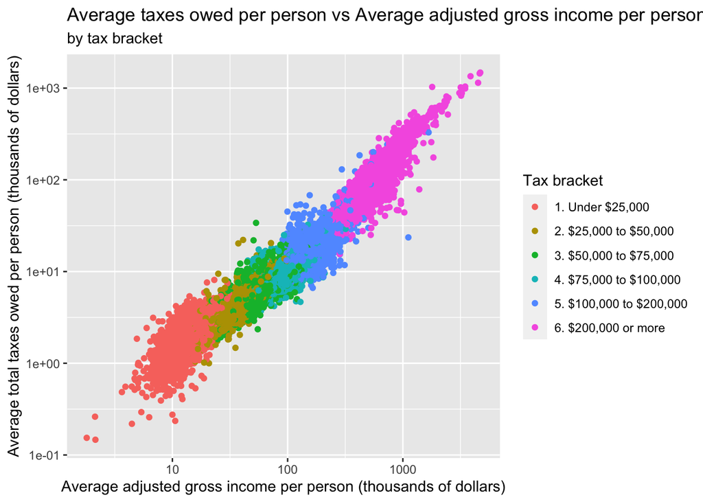

This scatter plot was included to analyze the relationship between two continuous variable: average total taxes owed per person and average adjusted gross income per person. It shows how the average amount taxes owed per person varies with the average adjusted gross income per person across the United States, by tax bracket. In general, the average amount of taxes owed person increases as the average adjusted gross income per person increases, which is expected. However, when considering the relationship between these two values between tax brackets, it is interesting to see how higher tax brackets owe a disproportionate amount of taxes. This is because we expect the average amount of total taxes owed to increase faster with average adjusted gross income for higher brackets, compared to lower brackets, but this is not the case, as shown in the scatter plot.

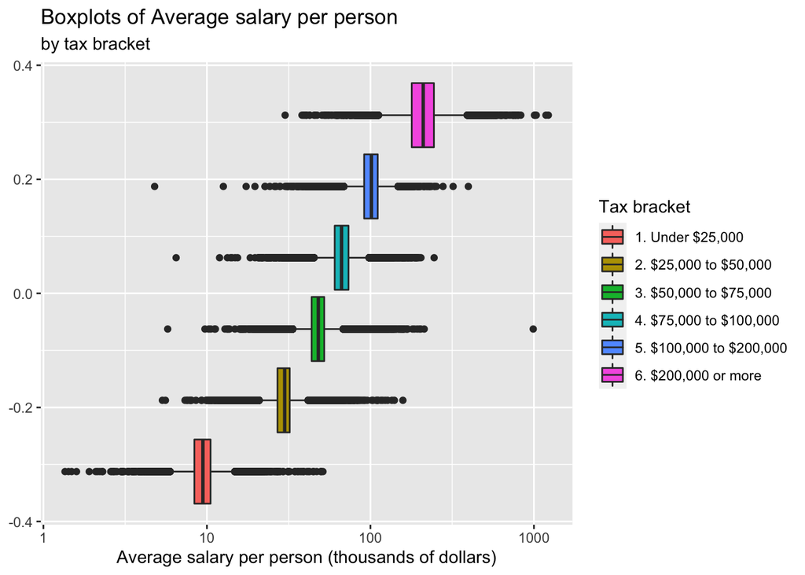

These box plots were included to explore the wages of individuals across tax brackets. They show the distributions of the average salary per person for each tax bracket. It is interesting to observe the number of average salaries that lie outside of the upper and lower bounds of each tax bracket. This indicates that there are a number of factors outside of a person’s salary that eventually determine which tax bracket they belong to. Also, the highest tax bracket has a visually larger interquartile range than all other tax brackets, as indicated by the width of the box. So, for the highest tax bracket, there is more variability in the middle 50% of average salaries per person compared to that of other brackets. In simple terms, this means that the middle half of the dollar amounts for average salary per person take on more values for the highest tax bracket compared to that of other tax brackets.

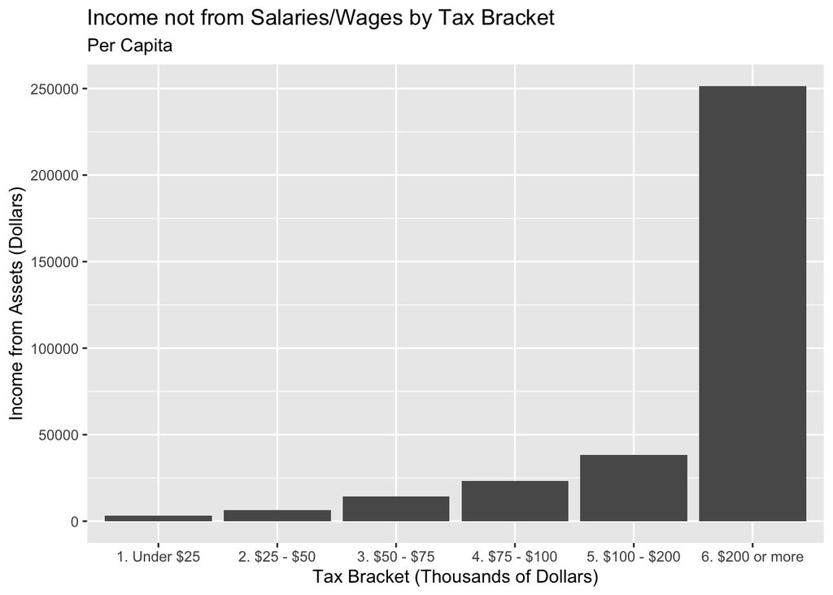

This chart shows the income that individuals accrue not from salaries or wages. It was calculated from subtracting income from salaries and wages from total income. This income represents mostly capital gains as well as passive income from cash-generating businesses. The most important aspect of this is that salaries are taxed more than capital gains. Capital gains tax maxes at 20%, while salary tax maxes at 37%. The chart shows that the top bracket earns an extreme amount more from capital gains, an average of $251,495 per person. Therefore, high earners are using the capital gains tax laws to pay less tax on their income. This law is much more exploitable for high earners who have the capital to fund portfolio investments. This is one of the most significant ways that wealthy individuals continue to become wealthier. This is an extremely relevant topic right now, as Joe Biden has proposed to raise the maximum capital gains tax from 20% to 39.6%. Therefore, for the highest bracket, capital gains will be effectively taxed as ordinary income. This will decrease the efficacy of this tax evasion strategy and promote equal paying of taxes.